# DSM 5012 Uygulamalı Zaman Serisi Analizi

24 06 2021

**Veri seti**

Veri setimiz aylık olarak Haziran 2017 ile Nisan 2021 arasında güneş enerjisiyle elde edilmiş elektrik miktarlarını içermektedir.

[figure not shown]

**Tanımlayıcı İstatistikler**

```r
summary(df$Gunes)
```

```
##    Min. 1st Qu.  Median    Mean 3rd Qu.    Max.
##  242795  430320  785811  706462  974139 1256838
```

```r
sd(df$Gunes)
```

```
## [1] 299013.1
```

- Aylık güneş enerjisiyle elde edilen elektrik miktarı 242795 MW ile 1256838 MW arasında 706462 ortalamayla 299013.1 MW standart sapmaya sahiptir.

**Zaman Serisi Analizi**

[output not shown]

[figure not shown]

Zaman serisi grafiğine baktığımızda;

- Trend bileşeni ve bununla birlikte mevsimsel bileşen içerdiği görülmektedir. Zaman serisindeki rastgele dalgalanmalar zaman içinde sabit gibi görünüyor, veriyi toplamsal model temsil edebilir.

**Zaman Serisinin Bileşenleri**

[figure not shown]

- Bu grafiktende anlaşılacağı gibi güneş enerjisinden elde edilen elektrik miktarı mevsimsel bileşen içermektedir.

**Zaman Serisinin Bileşenleri**

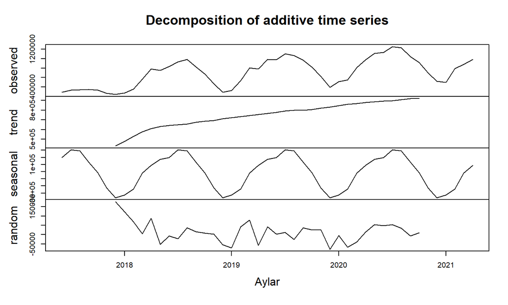

## HoltWinters Düzeltme Yöntemi

- Zaman serimizde hem trend hem de mevsimsellik bulunduğu için HoltWinters düzeltme yöntemi kullanımalıdır.
- Tahmini alpha, beta ve gamma değerleri sırasıyla 0.25, 0.11 ve 0.69’dur. Alpha 0.25 değeri düşüktür, bu da daha uzak geçmişteki bazı gözlemlere dayandığını gösterir.
- Beta değeri 0.11’dir, bu da trend bileşeninin b eğimi tahmininin zaman serilerinde başlangıç değerine yakın olarak ayarlandığını gösterir.
- Aksine, gamma değeri 0.69, bu da mevsimsel bileşenin mevcut zaman noktasındaki tahmininin son gözlemlere dayandığını gösterir.

```r
(df_forecasts<-forecast(df_bes, h=12))
```

```
##          Point Forecast     Lo 80     Hi 80     Lo 95     Hi 95
## May 2021      1150284.2 1022980.3 1277588.0  955589.7 1344978.6
## Jun 2021      1174451.5 1042416.6 1306486.4  972521.6 1376381.5
## Jul 2021      1277546.8 1139995.1 1415098.5 1067179.7 1487913.9
## Aug 2021      1250225.0 1106374.3 1394075.8 1030224.3 1470225.8
## Sep 2021      1083561.3  932644.2 1234478.4  852753.5 1314369.1
## Oct 2021       938318.1  779591.1 1097045.2  695566.0 1181070.2
## Nov 2021       716551.1  549299.8  883802.4  460762.4  972339.8
## Dec 2021       540604.1  364147.0  717061.2  270736.2  810472.0
## Jan 2022       575769.2  389458.5  762079.9  290831.5  860706.9
## Feb 2022       785292.4  588514.1  982070.8  484345.9 1086239.0
## Mar 2022       933648.0  725820.5 1141475.5  615803.3 1251492.7
## Apr 2022      1057492.5  838065.3 1276919.8  721907.6 1393077.5
```

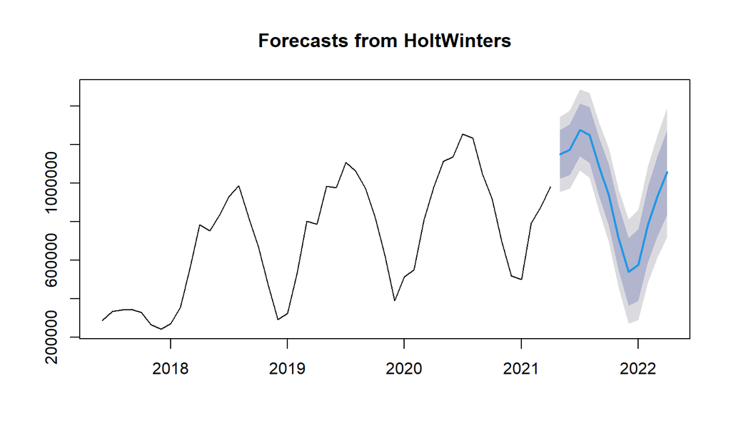

```r
plot(df_forecasts)
```

06.2017-04.2021 tahminlerini kullanarak 12 aylık ortalama güneş enerjisinden elde edilen elektrik miktarının tahminini yaptığımızda;

Örneğin; Mayıs 2021 için öngörülen ortalama elektrik miktarı %95 güvenle yaklaşık 955589.7 MW ile 1344978.6 MW arasında 1150284.2 MW’dır.

*ARIMA(p,d,q)*SARIMA(P,D,Q)[12] tanımlama*

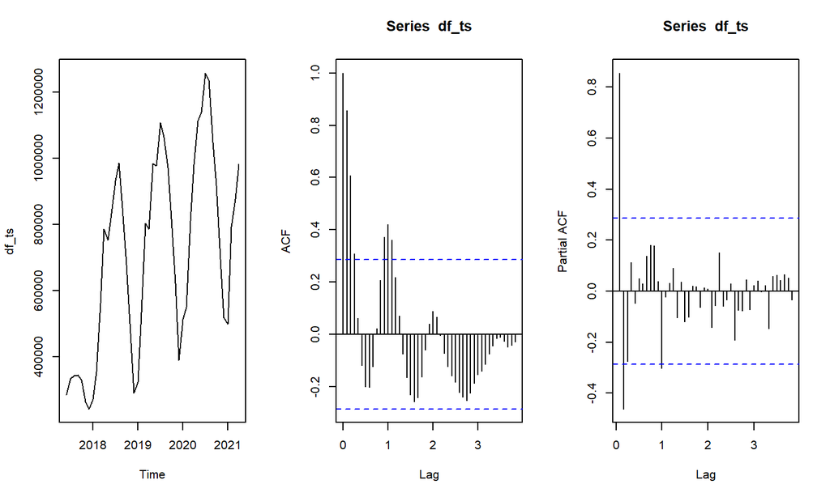

- Orijinal değerlerin otokorelasyon grafiğine baktığımızda zaman serimizin durağan olmadığını görülmektedir.
- Orijinal değerlerin kısmi otokorelasyon grafiğine baktığımızda 2. geçikmeden sonra cutoff olduğu görülmektedir.

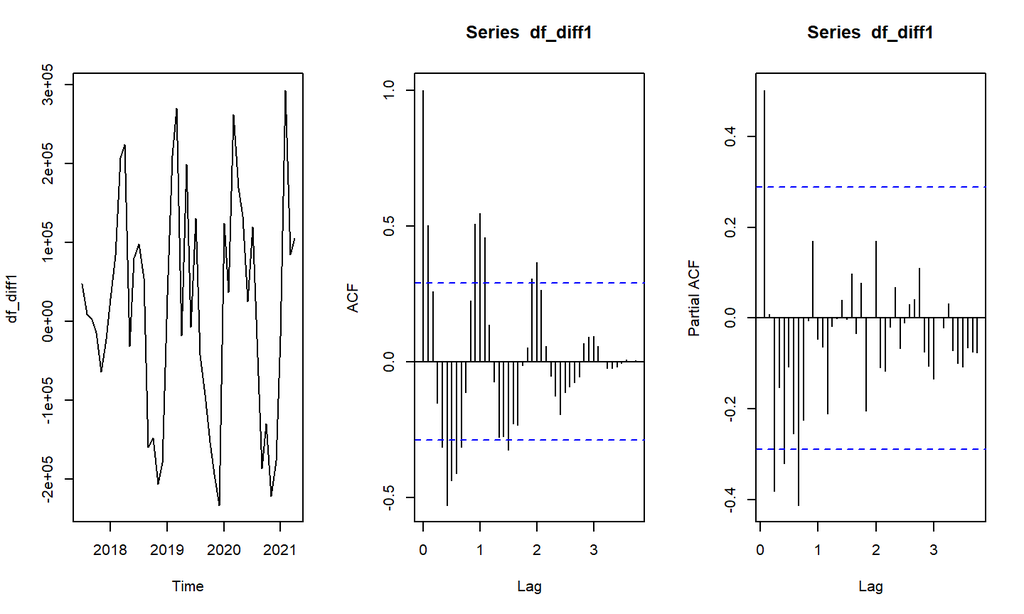

- Birinci dereceden farkı alınmış verilerin ortalamasının sıfır civarında olduğu görülmektedir.
- Birinci dereceden fark alınmış verilerin otokorelasyonun anlamlı olduğunu ve durağanlaşmadığını söyleyebiliriz.
- Birinci dereceden fark alınmış verilerin normal kısmına baktığımızda hızlıca azalma ya da ani düşüş görülmemektedir.

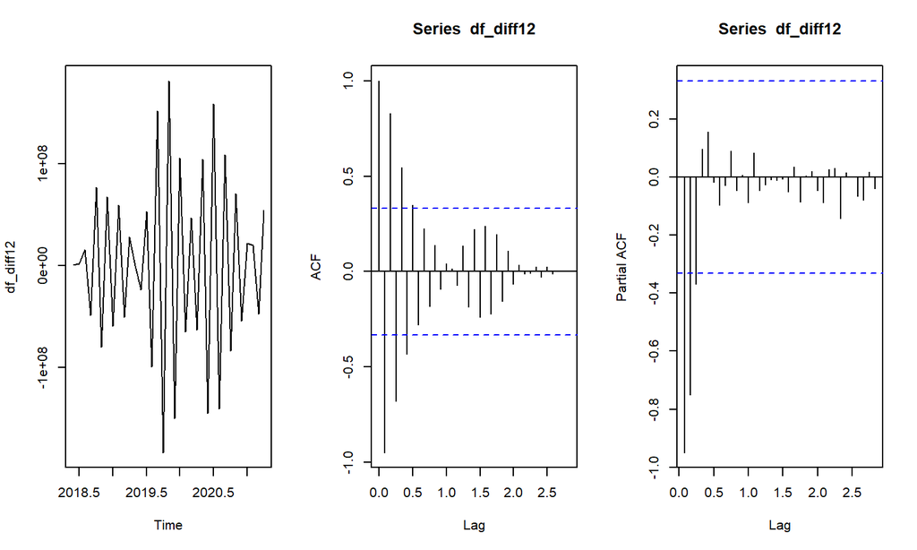

*Augmented Dickey-Fuller testine göre;*

\(H_{0}\): Seri durağan değildir.

\(H_{1}\): Seri durağandır.

- Orijinal seri için p-value değeri 0.016 çıkmıştır. Bu değer 0.05’ten küçük olduğu için \(H_{0}\) reddedilir. Orijinal seri durağandır.
- Birinci dereceden fark alınmış seri için p-value değeri 0.019 çıkmıştır. Bu değer 0.05’ten küçük olduğu için \(H_{0}\) reddedilir. 1. dereceden farkı alınmış seri durağandır.
- Birinci dereceden mevsimsel fark alınmış seri için p-value değeri 0.01 çıkmıştır. Bu değer 0.05’ten küçük olduğu için \(H_{0}\) reddedilir. 1. dereceden mevsimsel farkı alınmış seri durağandır.

*Phillips–Perron birim kök testine göre;*

\(H_{0}\): Seri durağan değildir.

\(H_{1}\): Seri durağandır.

- Orijinal seri için p-value değeri 0.208 çıkmıştır. Bu değer 0.05’ten büyük olduğu için \(H_{0}\) reddedilemez. Orijinal seri durağan değildir.
- Birinci dereceden fark alınmış seri için p-value değeri 0.016 çıkmıştır. Bu değer 0.05’ten küçük olduğu için \(H_{0}\) reddedilir. 1. dereceden farkı alınmış seri durağandır.
- Birinci dereceden mevsimsel fark alınmış seri için p-value değeri 0.01 çıkmıştır. Bu değer 0.05’ten küçük olduğu için \(H_{0}\) reddedilir. 1. dereceden mevsimsel farkı alınmış seri durağandır.

\(H_{0}\): Seri durağandır.

\(H_{1}\): Seri durağan değildir.

*ARIMA(2,0,0)*SARIMA(1,1,0)[12]*

```r
coeftest(model)
```

```
##
## z test of coefficients:
##
##      Estimate Std. Error z value  Pr(>|z|)
## ar1   0.73640    0.16618  4.4314 9.362e-06 ***
## ar2   0.24652    0.16807  1.4668    0.1424
## sar1 -0.61639    0.15142 -4.0706 4.689e-05 ***
## ---
## Signif. codes:  0 '***' 0.001 '**' 0.01 '*' 0.05 '.' 0.1 ' ' 1
```

**Artık analizi**

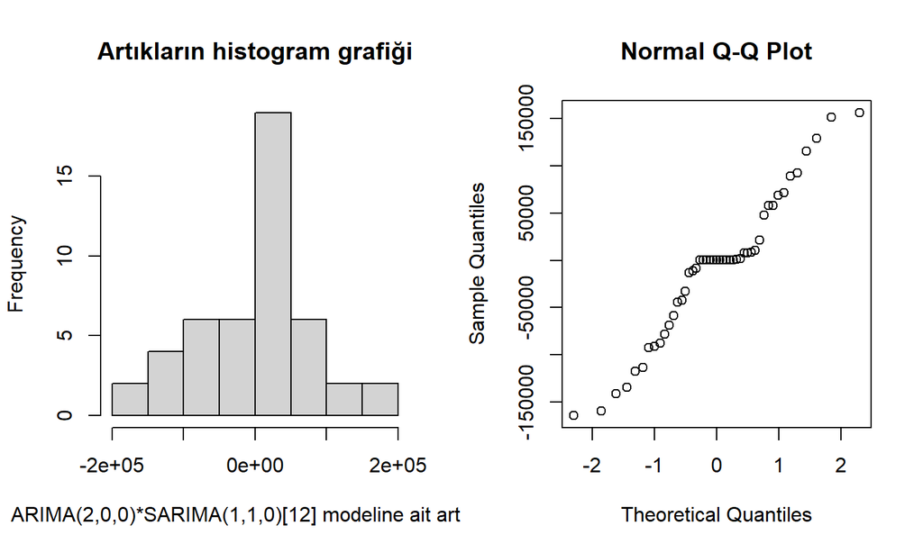

- Grafiğe baktığımızda artıkların normal dağıldığı görülmektedir yinede test edilmelidir.

*Shapiro testine göre;*

\(H_{0}\): Artıklar normal dağılır.

\(H_{1}\): Artıklar normal dağılmaz.

- 0.07938>0.05 olduğu için \(H_{0}\) reddedilemez. Artıklar normal dağılır.

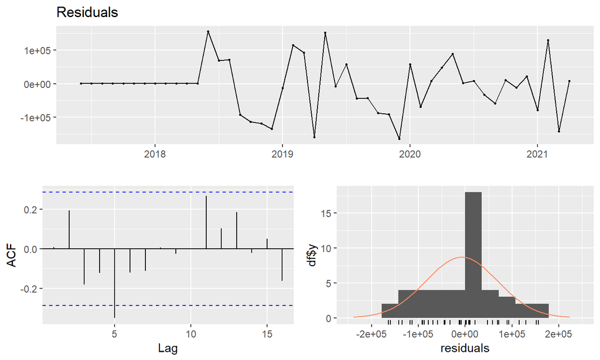

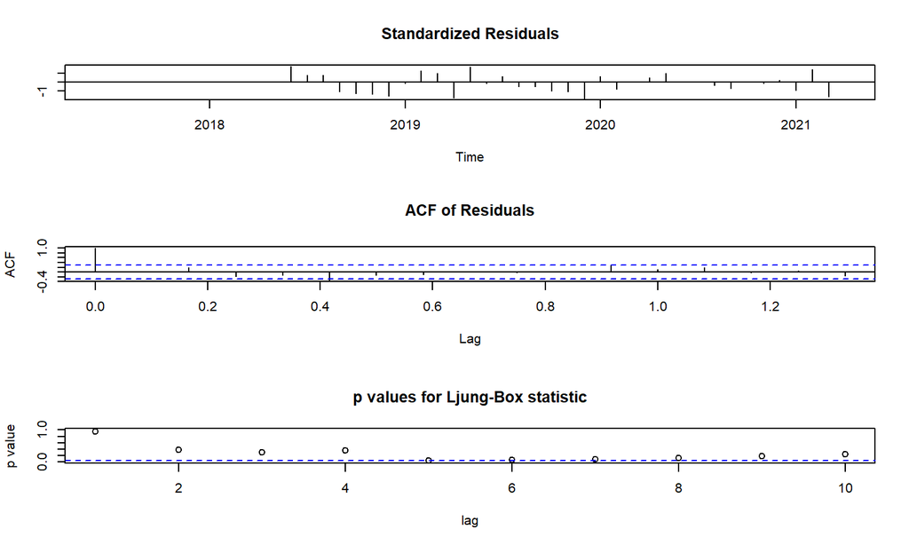

*Box-Pierce testi;*

\(H_{0}\): Artıklar otokorelasyona sahip değildir.

\(H_{1}\): Artıklar otokorelasyona sahiptir.

Box.teste göre;

- lag = 1’in p-value = 0.9544
- lag = 6’nın p-value = 0.1087
- lag = 12’nin p-value = 0.2476
- lag = 24’ün p-value = 0.0.3838

*Ljung-Boxa göre;*

\(H_{0}\): Artıklar otokorelasyona sahip değildir.

\(H_{1}\): Artıklar otokorelasyona sahiptir.

- lag = 1’in p-value = 0.9529
- lag = 6’nın p-value = 0.0638
- lag = 12’nin p-value = 0.1168
- lag = 24’ün p-value = 0.05073

Gecikmelerin 1, 6, 12, 24 bununla birlikte Box-Pierce ve Ljung–Box testlerine göre tüm p-value’lar 0.05’ten büyüktür. \(H_{0}\) reddedilemez. Artıklar otokorelasyona sahip değildir.

**Öngörümleme**

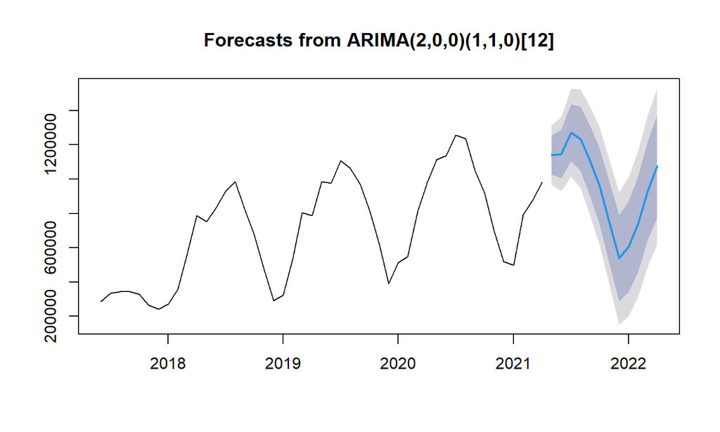

Örneğin; Mayıs 2021 için öngörülen ortalama elektrik miktarı %95 güvenle yaklaşık 966647.8 MW ile 1314376.7 MW arasında 1140512.3 MW’dır.

*ARIMA(3,0,0)*SARIMA(1,1,0)[12]*

```r
coeftest(model1)
```

```
##
## z test of coefficients:
##
##      Estimate Std. Error z value  Pr(>|z|)
## ar1   0.81689    0.16005  5.1039 3.327e-07 ***
## ar2   0.47737    0.21613  2.2087   0.02720 *
## ar3  -0.31863    0.19039 -1.6735   0.09422 .
## sar1 -0.71637    0.12791 -5.6007 2.134e-08 ***
## ---
## Signif. codes:  0 '***' 0.001 '**' 0.01 '*' 0.05 '.' 0.1 ' ' 1
```

**Artık analizi**

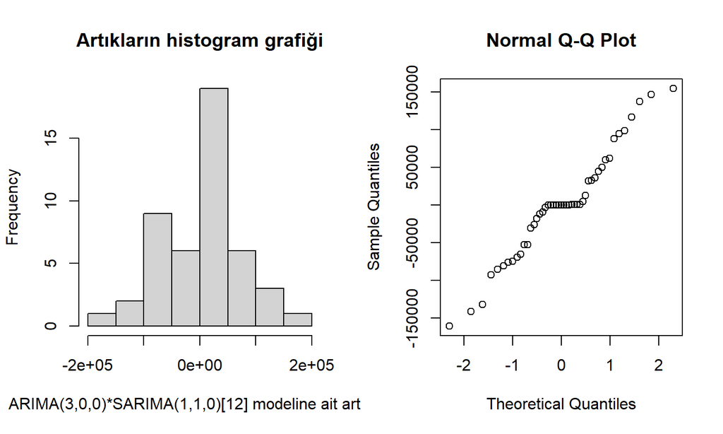

- Grafiğe baktığımızda artıkların normal dağıldığı görülmektedir yinede test edilmelidir.

*Shapiro testine göre;*

\(H_{0}\): Artıklar normal dağılır.

\(H_{1}\): Artıklar normal dağılmaz.

- 0.1349>0.05 olduğu için \(H_{0}\) reddedilemez. Artıklar normal dağılır.

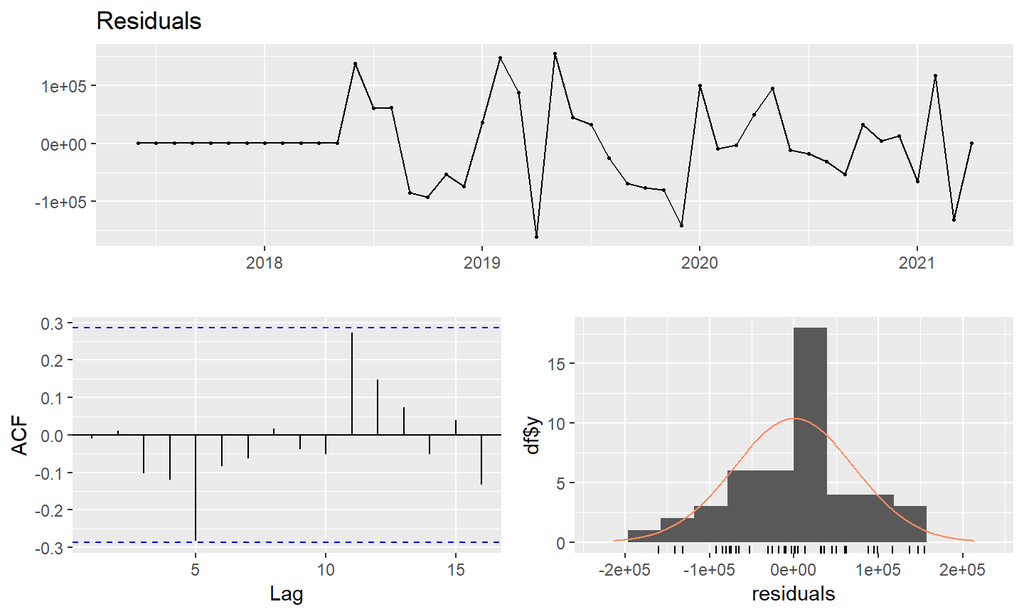

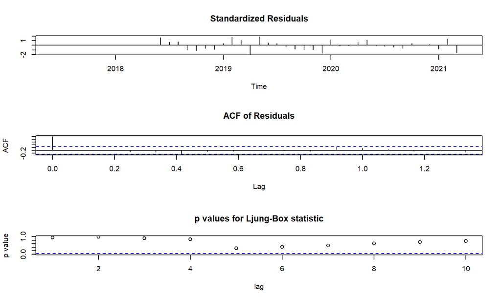

- İlk grafiğe baktığımızda standartlaştırılmış artıkların rassal bir sürece sahip olduğu söyleyebiliriz yinede test yapılmalıdır.
- İkinci grafiğe baktığımızda artıkların ototkorelasyona sahip olmadığını söyleyebiliriz.
- Üçüncü garfiğe baktığımızda p-value’ların giderek yavaşça azaldığını ve daha sonra tekrar arttığını söyleyebiliriz.

*Box-Pierce testi;*

\(H_{0}\): Artıklar otokorelasyona sahip değildir.

\(H_{1}\): Artıklar otokorelasyona sahiptir.

Box.teste göre;

- lag = 1’in p-value = 0.9445
- lag = 6’nın p-value = 0.5094
- lag = 12’nin p-value = 0.601
- lag = 24’ün p-value = 0.8891

*Ljung-Boxa göre;*

\(H_{0}\): Artıklar otokorelasyona sahip değildir.

\(H_{1}\): Artıklar otokorelasyona sahiptir.

- lag = 1’in p-value = 0.9427
- lag = 6’nın p-value = 0.4104
- lag = 12’nin p-value = 0.3848
- lag = 24’ün p-value = 0.5004

Gecikmelerin 1, 6, 12, 24 bununla birlikte Box-Pierce ve Ljung–Box testlerine göre tüm p-value’lar 0.05’ten büyüktür. \(H_{0}\) reddedilemez. Artıklar otokorelasyona sahip değildir..

**Öngörümleme**

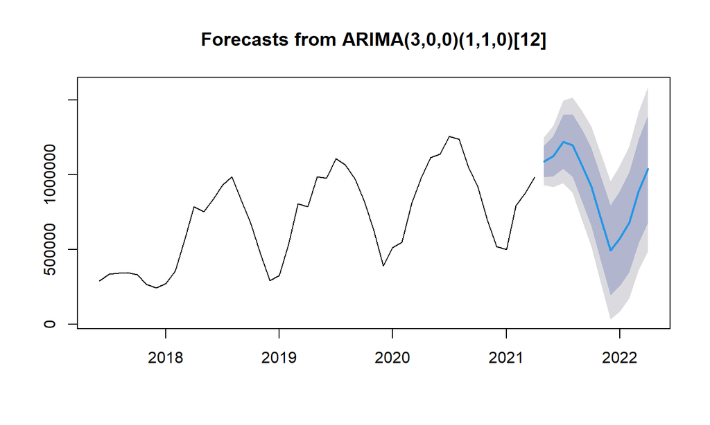

Örneğin; Mayıs 2021 için öngörülen ortalama elektrik miktarı %95 güvenle yaklaşık 928830.89 MW ile 1248807.9 MW arasında 1088819.4 MW’dır.

**Karar**

[figure not shown]

ARIMA(3,0,0)*SARIMA(1,1,0)[12] modeli hem bilgi kriterlerine göre hemde p-value değerlerin yüksekliği nedeniyle daha güvenilirdir.

## *Bizi Dinlediğiniz İçin Teşekkürler ☻*

[figure not shown]